# Evaluate concordance between Mutect2 and Strelka2

Candace Savonen - CCDL for ALSF

This notebook is a first pass in evaluating the concordance between MuTect2 and Strelka2 results.

It addresses [issue # 30 in OpenPBTA](https://github.com/AlexsLemonade/OpenPBTA-analysis/issues/30).

## Set Up

* Some of these set up steps will be removed once we have a Dockerfile that installs maftools automatically.

```r
if (!('colorblindr' %in% installed.packages())) {
devtools::install_github("clauswilke/colorblindr")
}
```

[output not shown]

[output not shown]

[output not shown]

[output not shown]

[output not shown]

[output not shown]

```
** testing if installed package can be loaded from final location
```

[output not shown]

```
** testing if installed package keeps a record of temporary installation path
* DONE (colorblindr)
```

Create a output directories.

```r
if (!dir.exists("results")) {
  dir.create("results")
}
if (!dir.exists("plots")) {
  dir.create("plots")
}
```

## Read in the metadata information

This will be changed once the [data download script](https://github.com/AlexsLemonade/OpenPBTA-analysis/issues/2) is finalized.

Prep the metadata to be used as the `clinicalData` for maftools it it hasn’t been prepped yet. This whole chunk may need to be removed be taken out after issue 2 regarding the [data download script](https://github.com/AlexsLemonade/OpenPBTA-analysis/issues/2) is addressed.

These steps are only to make the metadata and MuTect2 and Strelka2 datasets parallel in what samples they contain.  
There are some samples in the metadata that are not in the MuTect2 and Strelka2 data.

```r
if (file.exists(file.path("..", "..", "scratch", "metadata_filtered.tsv"))) {
  metadata <- readr::read_tsv(file.path("..", "..", "scratch", "metadata_filtered.tsv"))
}
```

Will read in as an `maftools` object from an RDS file, unless `maftools` has not been run on them yet. Running `maftools` takes a lot of computing power and time, so be prepared. If you trying to run this step in a Docker container, it will likely be out of memory killed, unless you have ~50GB you can allot to Docker.

```r
# Load in the RDS file if it exists, but if it doesn't exist, load in from
# original data file with maftools
if (!file.exists(file.path("..", "..", "scratch", "strelka2.RDS"))) {
  strelka <- maftools::read.maf(file.path("..", "..", "data", "strelka2.maf.gz"),
                                clinicalData = metadata)
  saveRDS(strelka, file.path("..", "..", "scratch", "strelka2.RDS"))
} else {
  strelka2 <- readRDS(file.path("..", "..", "scratch", "strelka2.RDS"))
}
```

This is how I set up `metadata_filtered.tsv`. This should not need to be ran again and won’t run again unless `metadata_filtered.tsv` is misplaced from the scratch file.

```r
if (!file.exists(file.path("..", "..", "scratch", "metadata_filtered.tsv"))) {
  # Isolate metadata to only the samples that are in the datasets
  metadata <- metadata %>%
    dplyr::filter(sample_id %in% mutect2@clinical.data$Tumor_Sample_Barcode) %>%
    dplyr::distinct(sample_id, .keep_all = TRUE) %>%
    readr::write_tsv(file.path("..", "..", "scratch", "metadata_filtered.tsv"))
}
```

Check that samples are same order in the datasets as they are in the metadata

```r
all.equal(as.factor(metadata$sample_id),
          strelka2@clinical.data$Tumor_Sample_Barcode)
```

```
[1] TRUE
```

```r
all.equal(as.factor(metadata$sample_id),
          mutect2@clinical.data$Tumor_Sample_Barcode)
```

```
[1] TRUE
```

## Get summaries and write them to TSVs

Get gene summaries and write to TSV files.

```r
strelka2_gene_sum <- maftools::getGeneSummary(strelka2) %>%
  readr::write_tsv(file.path("results",
                             "strelka2_gene_summary.tsv"))

mutect2_gene_sum <- maftools::getGeneSummary(mutect2) %>%
  readr::write_tsv(file.path("results",
                             "mutect2_gene_summary.tsv"))
```

Get sample summaries and write to TSV files.

```r
strelka2_sample_sum <- maftools::getSampleSummary(strelka2) %>%
  readr::write_tsv(file.path("results",
                             "strelka2_sample_summary.tsv"))

mutect2_sample_sum <- maftools::getSampleSummary(mutect2) %>%
  readr::write_tsv(file.path("results",
                             "mutect2_sample_summary.tsv"))
```

## Number of mutations per gene correlation

```r
combined_gene <- mutect2_gene_sum %>%
  dplyr::inner_join(strelka2_gene_sum, by = 'Hugo_Symbol') %>%
  reshape2::melt(id = 'Hugo_Symbol') %>%
  dplyr::mutate(dataset = as.character(grepl(".x$", variable))) %>%
  dplyr::mutate(dataset = dplyr::recode(dataset,
                                        `TRUE` = "mutect2",
                                        `FALSE` = "strelka2")) %>%
  dplyr::mutate(variable = gsub(".x$|.y$", "", variable)) %>%
  tidyr::spread('dataset', 'value')
```

Make number of mutations per gene scatterplots.

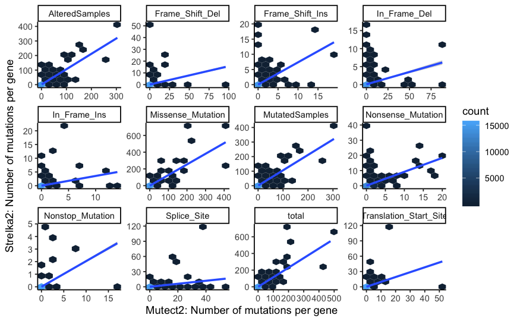

```r
gene_cor <- ggplot2::ggplot(combined_gene, ggplot2::aes(x = mutect2, y = strelka2)) +
  ggplot2::geom_hex(bins = 10) +
  ggplot2::facet_wrap(~variable, scales = "free") +
  ggplot2::geom_smooth(method = lm) +
  ggplot2::theme_classic() +
  ggplot2::xlab("Mutect2: Number of mutations per gene") +
  ggplot2::ylab("Strelka2: Number of mutations per gene")

# Print out the plot in this notebook
gene_cor
```

Save the plot to a PDF.

```r
ggplot2::ggsave(file.path("plots", "gene_cor_mutect2_vs_strelka2.pdf"))
```

Let’s get a correlation test on the genes overall.

```r
cor.test(combined_gene$mutect2, combined_gene$strelka2, method = "spearman")
```

```
Cannot compute exact p-value with ties
```

```
    Spearman's rank correlation rho

data:  combined_gene$mutect2 and combined_gene$strelka2
S = 4.2762e+13, p-value < 2.2e-16
alternative hypothesis: true rho is not equal to 0
sample estimates:
      rho
0.9604808
```

```r
cor.test(combined_gene$mutect2, combined_gene$strelka2, method = "pearson")
```

```
    Pearson's product-moment correlation

data:  combined_gene$mutect2 and combined_gene$strelka2
t = 580.42, df = 186550, p-value < 2.2e-16
alternative hypothesis: true correlation is not equal to 0
95 percent confidence interval:
 0.8006256 0.8038602
sample estimates:
      cor
0.8022488
```

## Number of mutations per sample correlation.

```r
combined_sample <- mutect2_sample_sum %>%
  dplyr::inner_join(strelka2_sample_sum, by = 'Tumor_Sample_Barcode') %>%
  reshape2::melt(id = 'Tumor_Sample_Barcode') %>%
  dplyr::mutate(dataset = as.character(grepl(".x$", variable))) %>%
  dplyr::mutate(dataset = dplyr::recode(dataset,
                                        `TRUE` = "mutect2",
                                        `FALSE` = "strelka2")) %>%
  dplyr::mutate(variable = gsub(".x$|.y$", "", variable)) %>%
  tidyr::spread('dataset', 'value')
```

Make number of mutations per sample scatterplots.

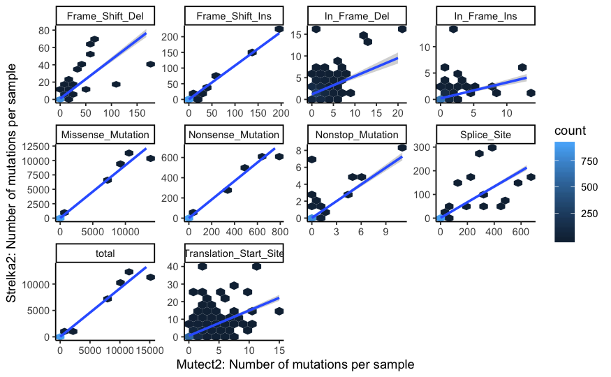

```r
sample_cor <- ggplot2::ggplot(combined_sample, ggplot2::aes(x = mutect2, y = strelka2)) +
  ggplot2::geom_hex(bins = 10) +
  ggplot2::facet_wrap(~variable, scales = "free") +
  ggplot2::geom_smooth(method = lm) +
  ggplot2::theme_classic() +
  ggplot2::xlab("Mutect2: Number of mutations per sample") +
  ggplot2::ylab("Strelka2: Number of mutations per sample")

# Print out the plot in this notebook
sample_cor
```

Save the plot to a PDF.

```r
ggplot2::ggsave(file.path("plots", "sample_cor_mutect2_vs_strelka2.pdf"))
```

```r
cor.test(combined_sample$mutect2, combined_sample$strelka2, method = "spearman")
```

```
Cannot compute exact p-value with ties
```

```
    Spearman's rank correlation rho

data:  combined_sample$mutect2 and combined_sample$strelka2
S = 2.8267e+10, p-value < 2.2e-16
alternative hypothesis: true rho is not equal to 0
sample estimates:
      rho
0.7749395
```

```r
cor.test(combined_sample$mutect2, combined_sample$strelka2, method = "pearson")
```

```
    Pearson's product-moment correlation

data:  combined_sample$mutect2 and combined_sample$strelka2
t = 720.76, df = 9098, p-value < 2.2e-16
alternative hypothesis: true correlation is not equal to 0
95 percent confidence interval:
 0.9909958 0.9917034
sample estimates:
      cor
0.9913568
```

## Calculate VAF

Set up data.frame with mutation and VAF for Strelka2.

```r
strelka2_vaf <- strelka2@data %>%
  dplyr::select(Hugo_Symbol, Allele, Tumor_Sample_Barcode, Start_Position,
                t_alt_count, t_ref_count, Reference_Allele) %>%
  dplyr::filter(!grepl("-", Allele)) %>%
  dplyr::mutate(vaf = as.numeric(t_alt_count)/(as.numeric(t_ref_count) +
                                                 as.numeric(t_alt_count)),
                mutation = paste0(Hugo_Symbol, "_",
                                  Allele, "_",
                                  Tumor_Sample_Barcode, "_",
                                  Start_Position),
                change = paste0(Reference_Allele, ">", Allele)) %>%
  dplyr::select(mutation, vaf, change)
```

```
NAs introduced by coercion
```

```r
# Take a look at this df
strelka2_vaf
```

| mutation | vaf | change |
| --- | --- | --- |
| SLC35E2A_T_BS_PJ08ZW9A_1734736 | 0.19444444 | C>T |
| RIF1_G_BS_PJ08ZW9A_151457959 | 0.14666667 | T>G |
| MUC4_C_BS_PJ08ZW9A_195788612 | 0.15000000 | T>C |
| TMEM63B_C_BS_PJ08ZW9A_44152627 | 0.16071429 | A>C |
| EPHB6_A_BS_PJ08ZW9A_142868665 | 0.38775510 | G>A |
| OGA_T_BS_PJ08ZW9A_101817872 | 0.90625000 | C>T |
| MAX_T_BS_PJ08ZW9A_65078029 | 0.46938776 | C>T |
| BRF1_T_BS_PJ08ZW9A_105252519 | 0.52542373 | C>T |
| TPSAB1_C_BS_PJ08ZW9A_1241317 | 0.16666667 | G>C |
| ZNF737_A_BS_PJ08ZW9A_20545230 | 0.09876543 | G>A |

[output cut: 990 more lines]

Set up data.frame with mutation and VAF for MuTect2.

```r
mutect2_vaf <- mutect2@data %>%
  dplyr::select(Hugo_Symbol, Allele, Tumor_Sample_Barcode, Start_Position,
                t_alt_count, t_ref_count, Reference_Allele) %>%
  dplyr::filter(!grepl("-", Allele)) %>%
  dplyr::mutate(vaf = as.numeric(t_alt_count)/(as.numeric(t_ref_count) +
                                                 as.numeric(t_alt_count)),
                mutation = paste0(Hugo_Symbol, "_",
                                  Allele, "_",
                                  Tumor_Sample_Barcode, "_",
                                  Start_Position),
                change = paste0(Reference_Allele, ">", Allele)) %>%
  dplyr::select(mutation, vaf, change)

# Take a look at this df
mutect2_vaf
```

| mutation | vaf | change |
| --- | --- | --- |
| NBPF10_CA_BS_CHAFNK64_146121575 | 0.11111111 | GT>CA |
| NBPF10_C_BS_CHAFNK64_146121585 | 0.10526316 | G>C |
| RGPD8_C_BS_CHAFNK64_112370198 | 0.11627907 | G>C |
| MUC4_C_BS_CHAFNK64_195782156 | 0.15625000 | T>C |
| MUC4_TC_BS_CHAFNK64_195782158 | 0.15151515 | CT>TC |
| ZDHHC11_C_BS_CHAFNK64_840529 | 0.06315789 | G>C |
| PCDHB16_C_BS_CHAFNK64_141184188 | 0.14285714 | A>C |
| METTL2B_CC_BS_CHAFNK64_128479325 | 0.09876543 | TG>CC |
| OTOGL_A_BS_CHAFNK64_80265019 | 0.10526316 | G>A |
| AHNAK2_C_BS_CHAFNK64_104945634 | 0.18750000 | T>C |

[output cut: 990 more lines]

Combine MuTect2 and Strelka2 VAF data.frames so we can compare.

```r
# Mutations common to both datasets:
vaf_df <- strelka2_vaf %>%
  dplyr::full_join(mutect2_vaf, by = 'mutation',
                    suffix = c(".strelka2", ".mutect2")) %>%
  dplyr::mutate(dataset = dplyr::case_when(
    is.na(vaf.mutect2) ~ "strelka2_only",
    is.na(vaf.strelka2) ~ "mutect2_only",
    TRUE ~ "both"))

# Take a look at this df
vaf_df
```

| mutation | vaf.strelka2 | change.strelka2 | vaf.mutect2 | change.mutect2 | dataset |
| --- | --- | --- | --- | --- | --- |
| SLC35E2A_T_BS_PJ08ZW9A_1734736 | 0.19444444 | C>T | NA | NA | strelka2_only |
| RIF1_G_BS_PJ08ZW9A_151457959 | 0.14666667 | T>G | 0.15277778 | T>G | both |
| MUC4_C_BS_PJ08ZW9A_195788612 | 0.15000000 | T>C | NA | NA | strelka2_only |
| TMEM63B_C_BS_PJ08ZW9A_44152627 | 0.16071429 | A>C | NA | NA | strelka2_only |
| EPHB6_A_BS_PJ08ZW9A_142868665 | 0.38775510 | G>A | 0.41666667 | G>A | both |
| OGA_T_BS_PJ08ZW9A_101817872 | 0.90625000 | C>T | NA | NA | strelka2_only |
| MAX_T_BS_PJ08ZW9A_65078029 | 0.46938776 | C>T | 0.48936170 | C>T | both |
| BRF1_T_BS_PJ08ZW9A_105252519 | 0.52542373 | C>T | 0.53448276 | C>T | both |
| TPSAB1_C_BS_PJ08ZW9A_1241317 | 0.16666667 | G>C | NA | NA | strelka2_only |
| ZNF737_A_BS_PJ08ZW9A_20545230 | 0.09876543 | G>A | NA | NA | strelka2_only |

[output cut: 990 more lines]

Plot this as a scatterplot

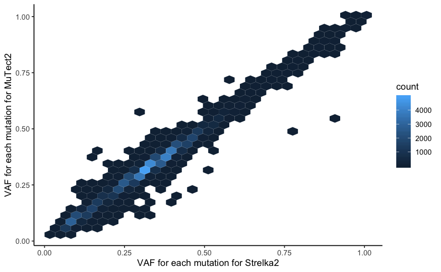

```r
vaf_df %>%
ggplot2::ggplot(ggplot2::aes(x = vaf.strelka2, y = vaf.mutect2)) +
  ggplot2::geom_hex() +
  ggplot2::theme_classic() +
  ggplot2::xlab("VAF for each mutation for Strelka2") +
  ggplot2::ylab("VAF for each mutation for MuTect2")
```

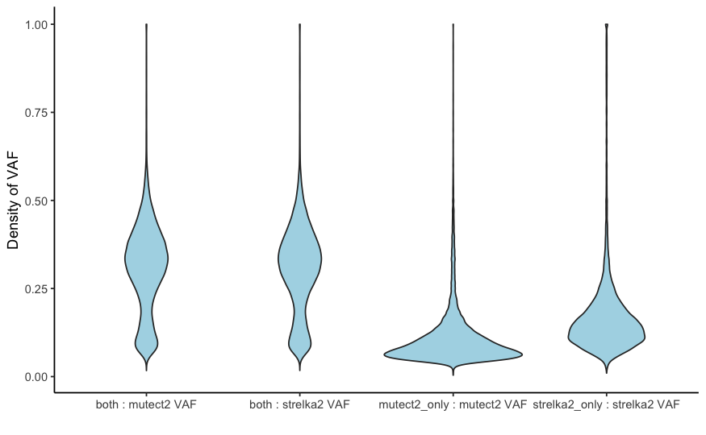

```r
vaf_df %>%
  tidyr::gather(key = "data", value = "vaf" , vaf.strelka2, vaf.mutect2) %>%
  dplyr::mutate(data = gsub("^vaf.", "", data)) %>%
  dplyr::mutate(data.group = paste(dataset, ":", data, "VAF")) %>%
  dplyr::filter(!is.na(vaf)) %>%
# Plot it
ggplot2::ggplot(ggplot2::aes(data.group, vaf)) +
  ggplot2::geom_violin(fill = "light blue") +
  ggplot2::theme_classic( ) +
  ggplot2::ylab("Density of VAF") +
  ggplot2::xlab(" ")
```

## Determine genes that are discordant.

```r
compare <- maftools::mafCompare(strelka2, mutect2, m1Name = "strelka2",
                                m2Name = "mutect2")
```

Get a data.frame of the genes that differ most.

```r
sig_diff_genes <- compare$results %>%
  dplyr::filter(adjPval < 0.05)
```

## Venn Diagrams

Make the Venn diagram of MuTect2 and Strelka2 mutations.

```r
count
```

```
         both  mutect2_only strelka2_only
        62181         23121         35012
```

```r
# Make the Venn diagram
grid::grid.newpage();
venn.plot <- VennDiagram::draw.pairwise.venn(
  area1 = count[3] + count[1],
  area2 = count[2] + count[1],
  cross.area = count[1],
  category = c("Strelka2", "MuTect2"),
  fill = c("blue", "yellow"),
  cex = 2,
  cat.cex = 1.5,
  cat.dist = c(-0.04, -0.031),
  ext.pos = 0,
  ext.dist = -0.01,
  ext.length = .8,
  ext.line.lwd = 2,
  ext.line.lty = "dashed");
```

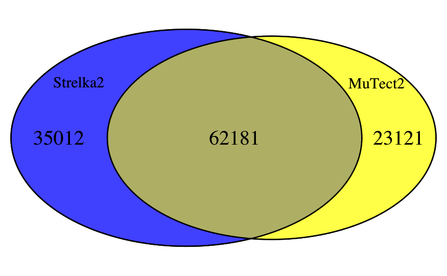

```r
grid::grid.draw(venn.plot) # Draw plot
```

Save the Venn Diagram plot to a PDF.

```r
# Make filename to save plot as
venn.plot.file <- file.path("plots",
                            "strelka2_mutect2_venn_diagram.pdf")
pdf(venn.plot.file);
grid::grid.draw(venn.plot);
dev.off()
```

## What types of variants are these?

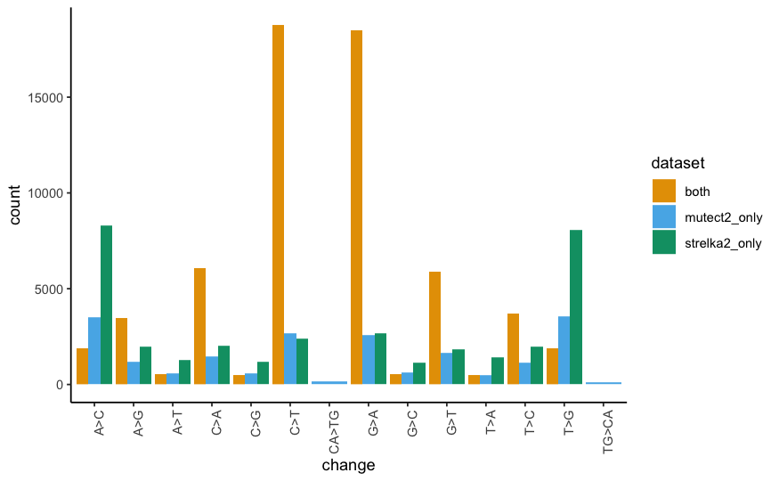

```r
vaf_df %>%
  dplyr::select(change.strelka2, change.mutect2, dataset) %>%
  tidyr::gather(key = "data", value = "change" , change.strelka2, change.mutect2) %>%
  dplyr::mutate('data' = gsub("^change.", "", data)) %>%
  dplyr::group_by(dataset, data, change) %>%
  dplyr::summarise(count = n()) %>%
  dplyr::filter(count > 100, !grepl("^->", change), !is.na(change)) %>%
  ggplot2::ggplot(ggplot2::aes(x = change, y = count, fill = dataset)) +
  ggplot2::geom_bar(position = "dodge", stat="identity") +
  ggplot2::theme_classic() +
  ggplot2::theme(axis.text.x = ggplot2::element_text(angle = 90, hjust = 1)) +
  colorblindr::scale_fill_OkabeIto()
```